# 第五單元：機率概論 with R

中山大學管理學院 卓雍然

2019-03-21 16:35:00

**學習重點：**使用R複習並練習操作「機率」的基本觀念

- 目標族群：Target Population
- 目標變數： Target Variable
- 樣本 vs. 樣本點 Sample vs. Point
- 隨機抽樣: sample()
- 重複實驗: replicate()
- 隨機變數: Random Variable
- 分布 Distribution
  - 類別 vs. 數值 樣本(向量)
  - 類別值 vs. 連續值分布 Discrete vs. Continuous
  - 數量分布 vs. 機率分布 Frequency vs. Density
  - 實證分布 vs. 理論分布 Empirical vs. Theoretical
  - 抽樣分布: Sampling Distribution

```r
pacman::p_load(dplyr)
```

### 【A】使用「向量物件」代表「族群」

為了方便討論，通常我們用一個類別或數量向量(factor or numeric vector)來代表某一個族群，向量之中的每一個值，代表族群之中的某一個研究對象。

##### A1. `Skin`：用類別向量代表族群之中的類別變數

產生一個長度為10的類別向量：`Skin`，用它來代表某一個10個人的族群當中每一個人的膚色

```r
Skin = rep(c("White","Yellow","Black","Others"), 1:4) %>% factor
Skin
```

```
 [1] White  Yellow Yellow Black  Black  Black  Others Others Others Others
Levels: Black Others White Yellow
```

用`table()`計算各分類(level)的數量

```r
table(Skin)
```

```
Skin
 Black Others  White Yellow
     3      4      1      2
```

用直條圖觀察各分類的數量

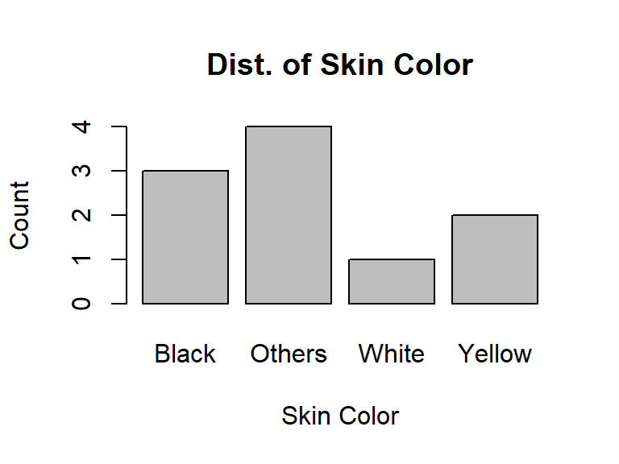

```r
table(Skin) %>%
  barplot(main="Dist. of Skin Color",xlab="Skin Color", ylab="Count")
```

##### A2. `Weight`：用數值向量代表族群之中的數值變數

產生一個長度為100的數值向量：Weight，，用它來代表某一個100個人的族群當中每一個人的體重

```r
set.seed(2)                         # set.seed for randomization
Weight = rnorm(100,mean=60,sd=5)    # 100 random samples
```

```r
Weight
```

```
  [1] 55.515 60.924 67.939 54.348 59.599 60.662 63.540 58.802 69.922 59.306
 [11] 62.088 64.909 58.037 54.802 68.911 48.445 64.393 60.179 65.064 62.161
 [21] 70.454 54.000 67.948 69.773 60.025 47.741 62.386 57.017 63.961 61.448
 [31] 63.695 61.595 65.381 58.579 56.117 57.022 51.370 55.487 57.205 58.767
 [41] 58.082 50.204 55.791 69.518 63.112 69.955 58.473 59.546 59.079 54.006
 [51] 55.809 70.332 57.189 66.379 54.762 50.171 58.385 64.679 65.696 68.358
 [61] 51.059 70.156 56.484 60.791 62.531 55.900 50.006 57.604 60.421 55.523
 [71] 55.394 61.652 59.292 62.174 59.731 55.464 66.518 63.859 65.263 52.950
 [81] 64.980 51.521 57.333 53.139 48.960 69.111 56.733 58.577 58.065 61.933
 [91] 68.002 68.406 54.082 53.208 52.437 53.734 69.797 60.038 55.787 56.994
```

用直方圖觀察它的數值分布，比較一下直條圖和直方圖有什麼異同

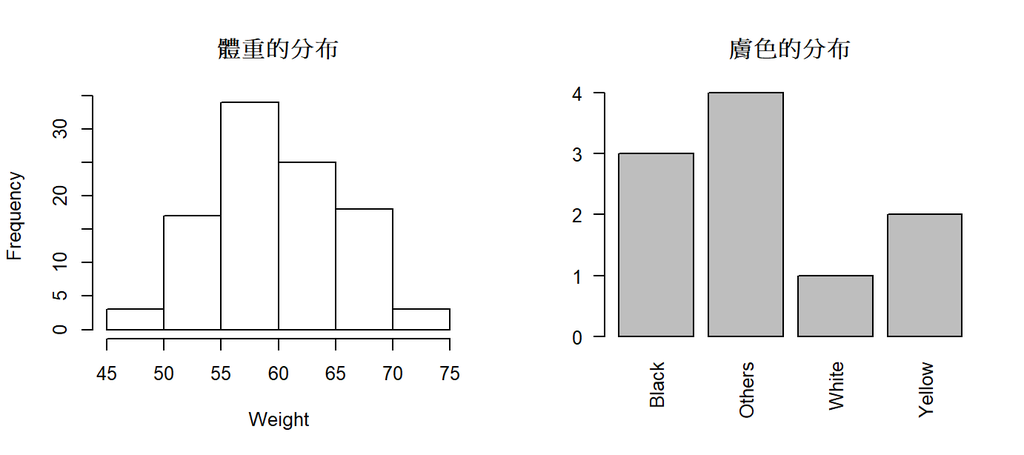

```r
par(mfrow=c(1,2), cex=0.8)
hist(Weight, main="體重的分布")
barplot(table(Skin), main="膚色的分布", xlab="", las=2)
```

🗿 問題討論：  
■ 直條圖和直方圖有什麼異同？  
■ 「分布」是什麼？  
■ 類別變數和數值變數的分布有什麼異同？

💡 學習重點：  
■ 分佈一般是指變數可能出現的值所出現的次數  
■ 類別變數可能出現的值是有限的，所以各分類出現的次數可以清楚的被計算出來  
■ 連續變數可能出現的值是無限的，所以我們需要指定數值區間，才能夠計算出現次數  
■ 該數值區間就是直方圖的「欄寬(binwidth)」

### 【B】數量分布和機率密度函數

如果我們改變直方圖的`binwdith`

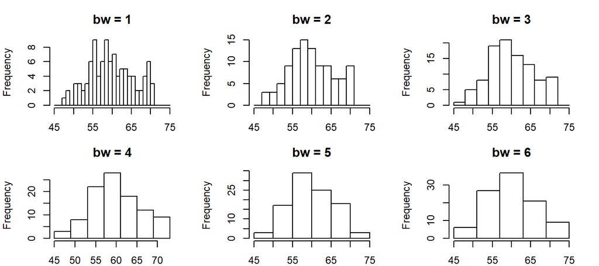

```r
par(mfrow=c(2,3), cex=0.75, mar=c(2,4,3,2))
for(bw in 1:6)
  hist(Weight, seq(45,75,bw), main=paste("bw =",bw),xlab="")
```

🗿: *`binwidth`代表什麼？ 它會如何改變直方圖的形狀？ 為甚麼？*

如果我們將族群增大為10,000人

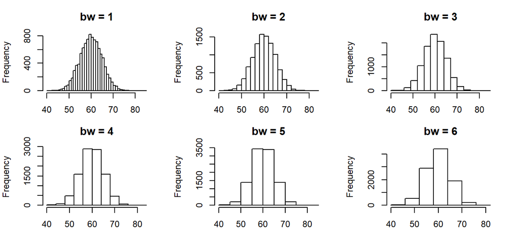

```r
set.seed(4); W10K = rnorm(10000,60,5)
for(bw in 1:6) {
  hist(W10K, breaks=seq(40,85,bw), main=paste("bw =",bw),xlab="")
  }
```

將Y軸從「次數(Frequency)」改為「密度(Density)」， 並且標上我們原先用來產生族群向量的「機率密度函數」

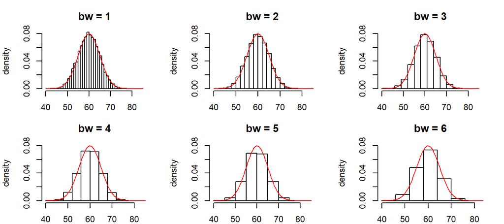

```r
for(bw in 1:6) {
  hist(W10K,breaks=seq(40,85,bw),freq=F,ylim=c(0,0.08),main=paste("bw =",bw),ylab="density")
  curve(dnorm(x,60,5),40,85,col='red',add=T)
  }
```

💡 學習重點：  
■ 族群太小時，太窄或太寬的binwidth都很容易扭曲數值分佈的形狀  
■ 族群夠大時，我們就可以用較窄的binwidth，讓直方圖逼近真實的數值分布  
■ binwidth趨近於零時，不連續的「直方圖」就會逼近連續的「數值分布函數」  
■ 等比例改變分布函數的高度，讓它下方的面積等於1，它就會變成「機率密度函數」  
■ 數值分布函數下方的面積代表族群中的數值落在某一區間的次數  
■ 機率密度函數下方的面積代表族群中的數值會落在某一區間的機率

🗿 問題討論：  
■ 直方圖和數量分布之間有什麼關係？  
■ 數量分布和機率函數之間有何異同？  
■ 機率函數下方的總面積是多大呢？

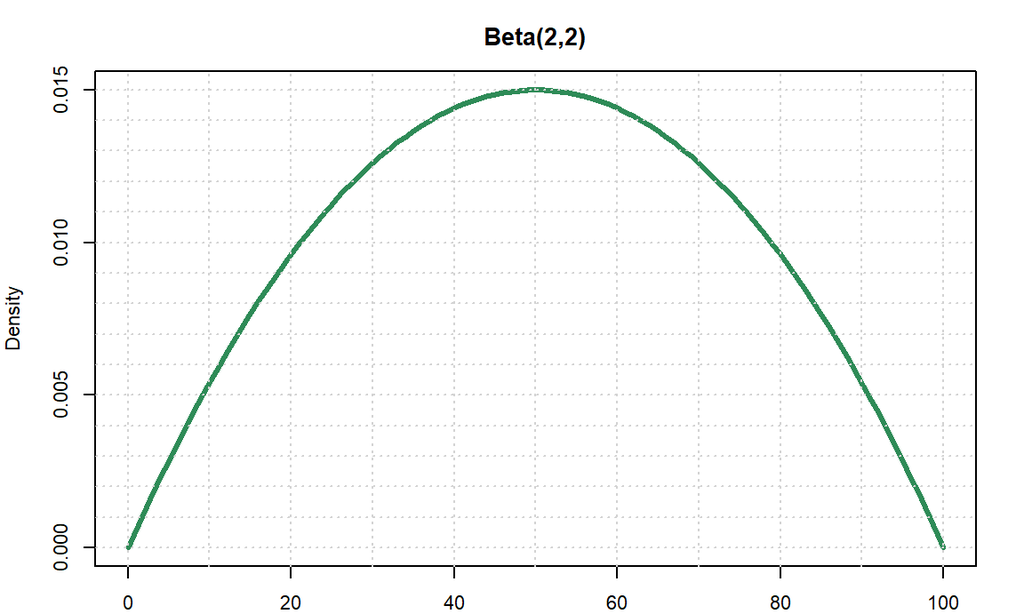

```r
W = 100
par(mfrow=c(1,1),cex=0.7)
curve(dbeta(x/W,2,2)/W,0,W,col='seagreen',lwd=3,main="Beta(2,2)",xlab="",y="Density")
abline(v=seq(0,W,W/10),h=seq(0,1.5,0.1)/W,col='lightgray',lty=3)
```

🗿 問題討論：  
■ 從以上機率密度函數抽出80,000個樣本點，大約有多少點會落在40跟60之間？  
■ 如果以上機率密度函數的底(support)變為`[0, 1]`，它的最高點會變成多少？  
■ 如果它的底變為`[0.95, 1.05]`，它的最高點會變成多少？

### 【C】個別抽樣的類別隨機變數

我們將隨機變數定義為隨機實驗的結果(值)，由於這些實驗帶有隨機的成份(也就是說每一次實驗都可能跑出不同的結果)，所以隨機變數的值是不確定的。

##### C1. 最簡單的隨機變數 - 類別目標變數、個別隨機抽樣

最簡單的隨機變數就是隨機從目標族群之中選取一點，直接就把這一點當作隨機變數的值。

##### C2. 個別隨機抽樣

使用`sample()`做個別隨機抽樣時，將樣本大小設為1 (`size=1`)

```r
sample(Skin, size=1)   # sample size = 1
```

```
[1] Yellow
Levels: Black Others White Yellow
```

##### C3. 重複實驗與結果向量

我們使用`replicate()`重複(隨機個別抽樣)實驗十次，將結果放在`skin1_10`這個類別向量裡面，由於`sample()`是從目標族群之中隨機抽樣，所以我們每一次執行這一段程式，所得到的類別向量都不會相同。

```r
skin1_10 = replicate(n=10, expr=sample(Skin, size=1))
skin1_10
```

```
 [1] Others Others Black  Black  White  Black  Others Others Yellow Black
Levels: Black Others White Yellow
```

##### C4. 比較族群和重複個別抽樣的結果

比較`Skin`和`skin1_10`之中各分類的比例

```r
Skin %>% table %>% prop.table
```

```
.
 Black Others  White Yellow
   0.3    0.4    0.1    0.2
```

```r
skin1_10 %>% table %>% prop.table
```

```
.
 Black Others  White Yellow
   0.4    0.4    0.1    0.1
```

🗿 問題討論：  
在這個例子裡面 …  
■ 我們的研究對象(分析單位)是？  
■ 目標族群？  
■ 目標變數？  
■ 隨機變數？  
當我們用一個類別向量來代表我們的目標族群時 …  
■ `Skin`代表什麼？  
■ `Skin[3:5]`代表什麼？  
這個例子我們討論『類別變數」的『個別抽樣』隨機變數，在這裡 …  
■ 我們如何定義我們的隨機變數？  
■ 我們如何產生隨機變數的值？  
當我將重複實驗的結果(值)存在`skin1_10`這個(類別的)『結果向量』裡面 …  
■ `skin1_10`代表什麼？  
■ `skin1_10[10]`代表什麼？  
■ `Skin`和`skin1_10`的長度各是多少？它們的長度是一樣的嗎？  
■ `Skin`和`skin1_10`之中各分類的比例是一樣的嗎？  
最後 …  
■ 「目標族群的大小」和「重複實驗的次數」一定要相同嗎？  
■ 目標族群和重複實驗的結果向量、兩者之中各分類的比例應該要相同(類似)嗎？

##### C5. 增加重複抽樣的次數

```r
t0 = Sys.time()
Trials = list(
  skin1_10 =   replicate(10, sample(Skin, size=1)),
  skin1_100 =  replicate(100, sample(Skin, size=1)),
  skin1_1K =   replicate(1000, sample(Skin, size=1)),
  skin1_10K =  replicate(10000, sample(Skin, size=1)),
  skin1_100K = replicate(100000, sample(Skin, size=1))
  )
Sys.time() - t0
```

```
Time difference of 4.7524 secs
```

`Trials`的子物件長度

```r
sapply(Trials, length)
```

```
  skin1_10  skin1_100   skin1_1K  skin1_10K skin1_100K
        10        100       1000      10000     100000
```

重複個別抽樣的結果之之中各分類的比例

```r
sapply(Trials, function(v) {
  prop.table(table(v))
  })
```

```
       skin1_10 skin1_100 skin1_1K skin1_10K skin1_100K
Black       0.2      0.23    0.290    0.3005    0.29749
Others      0.6      0.46    0.404    0.3943    0.40222
White       0.0      0.12    0.118    0.0987    0.09976
Yellow      0.2      0.19    0.188    0.2065    0.20053
```

### 【D】個別抽樣的數值隨機變數

接下來我們將隨機變數定義在數值變數(如`Weight`)之上，我們同樣可以用重複抽樣產生一系列的結果向量

```r
Trials = list(
  weight1_10 =   replicate(10, sample(Weight, size=1)),
  weight1_100 =  replicate(100, sample(Weight, size=1)),
  weight1_1K =   replicate(1000, sample(Weight, size=1)),
  weight1_10K =  replicate(10000, sample(Weight, size=1)),
  weight1_100K = replicate(100000, sample(Weight, size=1))
  )
```

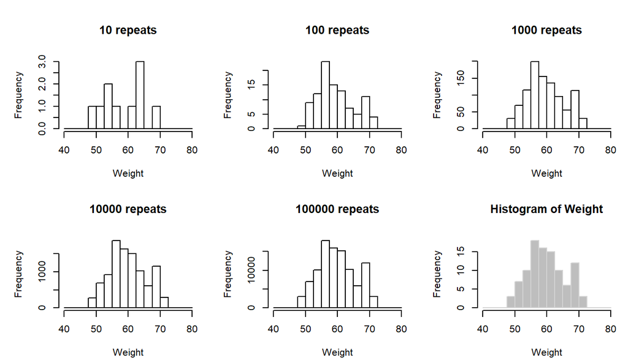

```r
par(cex=0.75, mfrow=c(2,3), mar=c(4,5,5,1))
for(v in Trials) {
  hist(v,breaks=seq(40,80,2.5),main=paste(length(v),"repeats"),xlab="Weight")
  }
hist(Weight, breaks=seq(40,80,2.5), col='gray', border='lightgray' )
```

💡 學習重點：  
關於『隨機變數』 …  
■ 隨機變數是定義在隨機實驗上面， 隨機實驗的結果就是隨機變數的值  
■ 我們透過實驗來產生隨機變數的值，由於實驗的結果是隨機的， 所以隨機變數的值也是不確定的  
■ 一般我們將重複實驗(N次)的結果存放在一個向量裡面，稱它為(重複N次的)『結果向量』  
■ 由於隨機變數的值不確定，所以通常我們關心的是它的『分布(Distribution)』  
■ 所謂『分布』就是結果向量之中各類別(或數值區間)出現的頻率  
隨機變數可以分為『類別』與『數值』兩大類 …  
■ 類別隨機變數的分布：各類別的比例，通常以直條圖表示  
■ 數值隨機變數的分布：變數在數值空間之中的分布頻率(或機率)， 通常以直方圖(或密度函數)表示  
『個別抽樣』可以說是最簡單的隨機變數 …  
■ 定義：從某一族群之中隨機選取一點， 直接以其值作為隨機變數的值  
■ 我們用`sample()`做隨機抽樣，個別抽樣實驗的樣本大小：`size = 1`  
■ 我們用`replicate(n,sample(.))`來重複實驗， 重複實驗的次數(`n`)不必與目標族群的大小相同  
對定義在『個別抽樣』實驗之上的類別(數值)隨機變數而言 …  
■ 重複實驗的結果和族群之中各分類的比例(數值的分布)並不會完全一樣  
■ 重複的次數越多，兩者之間的差異就會越來越小  
■ 理論上，重複“無窮”多次時， 結果向量中各分類的比例(數值分布)就會趨近於族群之中的比例(分布)

##### 補充教材：練習使用`%>%`和`lapply()`

善用`%>%`和`lapply()`可以降低程式的複雜度，也可以避免留下沒有用的(中間暫存)資料物件

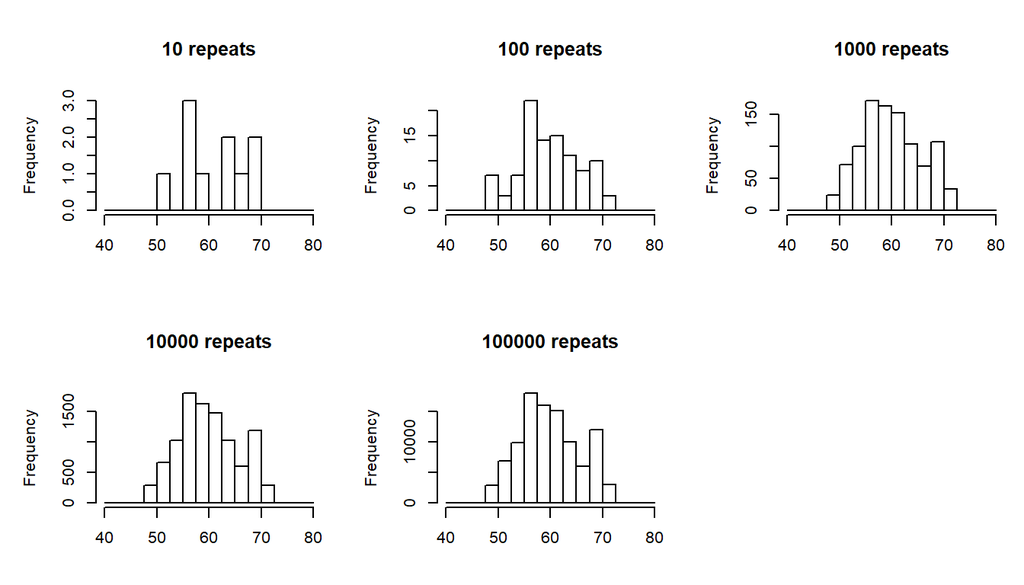

```r
lapply(10^(1:5), replicate, sample(Weight, 1)) %>% lapply(function(v) {
  hist(v, breaks=seq(40,80,2.5), main=paste(length(v),"repeats"), xlab="")
  }) -> z
```